# Medulloblastoma tissues RNAseq tumor immune cells deconvolution

# Introduction

This notebook presents an analysis of RNA sequencing data from Medulloblastoma tissues to perform tumor immune cell deconvolution. The analysis involves loading the necessary libraries, processing metadata and count data, mapping Ensembl IDs to HGNC symbol IDs, and performing immune cell deconvolution using the `immunedeconv` package.

# 1. Setup and Libraries

# 2. Load Feature Counts Data

We begin by loading the feature counts table containing the RNA sequencing data from Medulloblastoma tissues.

```r
canonical_RNA_counts_all <- read.table("/hpc/pmc_vanheesch/projects/Damon/Medulloblastoma_ORFs/Medulloblastoma_analyses_final/rnaseq_regular/data/processed/featurecounts/medullo_allsamples.counts", check.names = FALSE)
```

# 3. Process Metadata

Next, we load and process the metadata table associated with the RNA sequencing data.

```r
sample_metadata <- readxl::read_xlsx("/hpc/pmc_vanheesch/projects/Damon/Medulloblastoma_ORFs/Medulloblastoma_analyses_final/01.26.2023_Table_S1.xlsx", sheet = 1, col_names = TRUE, skip = 2, .name_repair = "universal")
# Filter samples with both RNAseq and riboseq data
sample_metadata_complete <- sample_metadata %>%
  filter(!is.na(RNASeq_file_names) &
           !is.na(RiboSeq_file_names..final.))

# Extract RNA sample names based on filenames
sample_metadata_complete <- sample_metadata_complete %>%
  mutate(rna_name = gsub("_R1.*", "", gsub(";.*", "", RNASeq_file_names)))

# Select metadata for tissue samples and convert factors
sample_metadata_tissues <- sample_metadata_complete %>%
  filter(Sample_Type != "Cell line") %>%
  mutate(MYC.group = as.factor(MYC.group),
         Molecular.subgroup = case_when(
           Molecular.subgroup == "Group 4" ~ "G4",
           Molecular.subgroup == "Group 3" ~ "G3",
           TRUE ~ Molecular.subgroup
         ))

# Set rownames to Sample_ID for easy indexing
rownames(sample_metadata_tissues) <- sample_metadata_tissues$Sample_ID
```

# 4. Data Preprocessing

In this section, we perform data preprocessing steps such as fixing sample column names, extracting length information, filtering and matching counts data, and calculating TPM values.

```r
# Fix sample column names by removing unnecessary parts
colnames(canonical_RNA_counts_all) <- basename(colnames(canonical_RNA_counts_all)) %>%
  gsub(".Aligned.sortedByCoord.out.bam", "", .)

# Extract length information
lengths <- canonical_RNA_counts_all$Length

# Extract counts data
counts <- canonical_RNA_counts_all[, 6:ncol(canonical_RNA_counts_all)]

# Match the column names of counts with the RNASeq_file_names in sample_metadata_tissues
match_counts <- unique(str_extract(sample_metadata_tissues$RNASeq_file_names, str_c(colnames(counts), collapse = "|")))
counts <- counts[, match_counts]

# Find matching metadata based on the matched column names
metadata_matches <- grep(paste(match_counts, collapse = "|"), sample_metadata_tissues$RNASeq_file_names)
sample_metadata_tissues <- sample_metadata_tissues[metadata_matches, ]
colnames(counts) <- sample_metadata_tissues$Sample_ID

# Calculate RPK (Reads Per Kilobase)
rpk <- sweep(counts, 2, lengths / 1000, "/")
# Calculate the sum of RPK values for each sample (library size)
lib_sizes <- colSums(rpk)

# Divide each RPK value by the library size (in millions) to get TPM
tpm <- sweep(rpk, 2, lib_sizes / 10^6, "/")
```

# 5. Map Ensembl IDs to HGNC Symbol IDs

In this step, we map Ensembl IDs to HGNC symbol IDs using the `org.Hs.eg.db` package. We handle duplicates and remove rows with missing symbols.

```r
# Map Ensembl IDs to HGNC symbol IDs
symbols <- mapIds(org.Hs.eg.db, keys = rownames(tpm), column = "SYMBOL", keytype = "ENSEMBL", multiVals = "first")
# Create a logical vector indicating rows with missing symbols
nas <- is.na(symbols)

# Remove rows with missing symbols from the 'tpm' dataframe
tpm <- tpm[!nas, ]

# Replace row names with unique HGNC symbol IDs
symbols_unique <- symbols[!nas]

# Handle duplicates by adding a suffix
dupes <- duplicated(symbols_unique)
symbols_unique[dupes] <- paste(symbols_unique[dupes], "_dup", seq(sum(dupes)), sep = "")

rownames(tpm) <- symbols_unique
```

# 6. Perform Tumor Immune Cell Deconvolution

Using the processed TPM values, we perform tumor immune cell deconvolution using the `immunedeconv` package and the “quantiseq” method.

```r
deconv <- immunedeconv::deconvolute(tpm, method = "quantiseq", tumor = TRUE)
```

```
>>> Running quantiseq

Running quanTIseq deconvolution module

Gene expression normalization and re-annotation (arrays: FALSE)

Removing 17 noisy genes

Removing 15 genes with high expression in tumors

Signature genes found in data set: 132/138 (95.65%)

Mixture deconvolution (method: lsei)

Deconvolution successful!
```

# 7. Visualization

## 7.1. Plotting Cell Fractions

To visualize the cell fractions in each sample, we reshape the deconvolution results to long format and create a stacked bar plot.

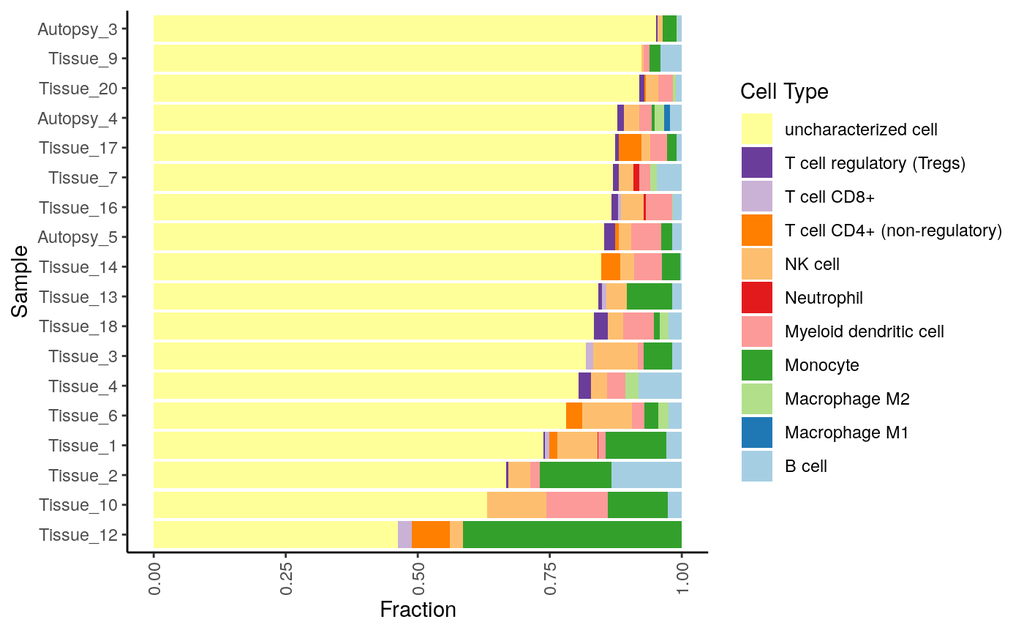

```r
# Reshape the data to long format for plotting
deconv_long <- deconv %>%
  gather(sample, fraction, -cell_type)

# Create a new variable 'sample_ordered' that is ordered by the fraction of "uncharacterized cell"
deconv_long <- deconv_long %>%
  mutate(sample_ordered = forcats::fct_reorder(sample, fraction * (cell_type == "uncharacterized cell"), .fun = sum))

# Create the plot
ggplot(deconv_long, aes(x = sample_ordered, y = fraction, fill = cell_type)) +
  geom_bar(stat = "identity") +
  theme_classic() +
  theme(axis.text.x = element_text(angle = 90, vjust = 0.5, hjust = 1)) +
  labs(x = "Sample", y = "Fraction", fill = "Cell Type") +
  guides(fill = guide_legend(reverse = TRUE))  +
  coord_flip() +
  scale_fill_brewer(palette = "Paired") +
  scale_x_discrete(limits = rev(levels(deconv_long)))
```

```r
# ggsave("/hpc/pmc_vanheesch/projects/Damon/Medulloblastoma_ORFs/Medulloblastoma_analyses_final/rebuttal_analyses/tissue_analyses/plots/RNAseq_immune_infiltration_tissues.pdf")
```

## 7.2. Hierarchical Clustering and Dendrogram

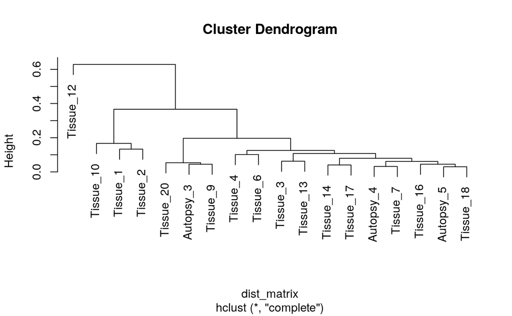

```r
# Transpose the deconvolution results
deconv_transposed <- t(deconv[, -1])

# Compute the distance matrix
dist_matrix <- dist(deconv_transposed, method = "euclidean")

# Perform hierarchical clustering
hc <- hclust(dist_matrix, method = "complete")


# pdf(file = "/hpc/pmc_vanheesch/projects/Damon/Medulloblastoma_ORFs/Medulloblastoma_analyses_final/rebuttal_analyses/tissue_analyses/plots/RNAseq_immune_infiltration_tissues_clustering.pdf")
# Plot the dendrogram
plot(hc, labels = hc$labels)
abline(h = cutree(hc, k = 3), col = "red")
```

```r
# dev.off()
```